# 2D Electrostatics Simulation using the Jacobi Relaxation Method

Welcome to my GitHub repository showcasing a 2D electrostatics simulation implemented using the Jacobi relaxation method. This project serves as a practical exploration of computational physics, where we simulate the behavior of electric fields in a 2D grid.

## Purpose and Motivation

The main objective of this project is to demonstrate how computational techniques can be employed to visualize and analyze electric fields, a fundamental concept in physics. By implementing the Jacobi relaxation method, we gain insights into the behavior of charges and voltages in a 2D space, providing a bridge between theoretical concepts and numerical solutions.

## Skills and Tools

Proficiency in Python programming for scientific computing. Effective utilization of NumPy for numerical operations. Data visualization using Matplotlib to create clear and informative plots.

## Educational Insight: Jacobi Relaxation Method

For those unfamiliar with the relaxation method, it's a technique used to solve partial differential equations by iteratively updating values until they converge to a solution. In our context, we use it to model how charges influence voltages in an electrostatic field. Think of it as simulating the "settling" of voltages in a grid, akin to the ripples calming down after you drop a pebble into a pond.

## Application in Electrostatics

In real life, the relaxation method finds critical application in analyzing complex electrostatics scenarios. Imagine designing a circuit board with intricate wiring patterns. Calculating voltages at every point manually would be time-consuming. Instead, by applying the relaxation method, we can quickly predict voltage distributions, optimizing the circuit's performance and ensuring the desired behavior.

### Example:

A cellphone's touch screen relies on capacitive sensing, where charges accumulate on electrodes. Using the relaxation method, engineers can predict the voltage distribution across the screen, enhancing touch sensitivity and accuracy.

Hope this repository serves as an educational tool for those interested in computational physics. Feel free to explore the code, run the simulations, and explore electrostatics through computation!

[figure not shown]

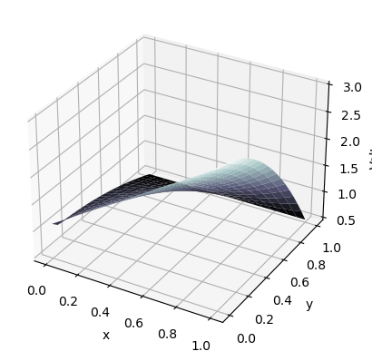

```python
import numpy as np
import matplotlib.pyplot as plt
from mpl_toolkits.mplot3d import Axes3D

def two_dimension_jacobi(schematic, boundary_location, error_threshold, middle_matrix):
    height, width = schematic.shape
    input_matrix = schematic.copy()
    output_matrix = schematic.copy()
    second_matrix = schematic.copy()

    iterations = 0
    delta_v = 0

    while True:
        for i in range(1, width - 1):
            for j in range(1, height - 1):
                if (i, j) not in boundary_location:
                    output_matrix[i, j] = (
                        input_matrix[i - 1, j]
                        + input_matrix[i - 1, j - 1]
                        + input_matrix[i - 1, j + 1]
                        + input_matrix[i + 1, j]
                        + input_matrix[i + 1, j - 1]
                        + input_matrix[i + 1, j + 1]
                        + input_matrix[i, j - 1]
                        + input_matrix[i, j + 1]
                    ) / 8
                    delta_v += abs(input_matrix[i, j] - output_matrix[i, j])

        iterations += 1
        if iterations == middle_matrix:
            second_matrix = output_matrix.copy()

        if delta_v < error_threshold:
            break
        else:
            delta_v = 0
            input_matrix = output_matrix.copy()

    return output_matrix, second_matrix, iterations, delta_v

def plot_results(box, output_matrix, iterations):
    fig, axs = plt.subplots(1, 3, figsize=(15, 5))
    axs[0].imshow(box, cmap="bone")
    axs[1].imshow(output_matrix[1], cmap="bone")
    axs[2].imshow(output_matrix[0], cmap="bone")
    titles = ['Voltage after 0 Iterations', f'Voltage after {iterations} iterations', f'Voltage after {iterations} Iterations']
    for ax, title in zip(axs, titles):
        ax.set_title(title)
    plt.tight_layout()

    fig1 = plt.figure()
    ax1 = fig1.add_subplot(111, projection="3d")
    x = np.linspace(0, width, bins)
    y = np.linspace(0, height, bins)
    x, y = np.meshgrid(x, y)
    ax1.plot_surface(x, y, output_matrix[0], cmap="bone")
    ax1.set_xlabel("x")
    ax1.set_ylabel("y")
    ax1.set_zlabel("Voltage")

    plt.show()

# Constants
A, B, C, D, E = 1, 2, 0.5, 3, 2.5
deciVolt, milliVolt = 0.1, 0.001
width, height = 1, 1
bins = 20
dx = width / bins
minima, maxima = -1.0, 1.0
box = np.zeros((bins, bins), dtype=float)
boundary_location = []

for i in range(bins):
    box[i][0] = A - C * (dx * (i + 1)) ** 2
    box[i][bins - 1] = D - E * (dx * (i + 1)) ** 2
    box[0][i] = A + B * (dx * (i + 1))
    box[bins - 1][i] = A / 2
    boundary_location.extend([(i, 0), (i, width - dx), (0, i), (width - dx, i)])

output_matrix, second_matrix, iterations, delta_v = two_dimension_jacobi(
    box, boundary_location, milliVolt, middle_matrix=10
)

plot_results(box, [output_matrix, second_matrix], iterations)
```